# M2: Data Cleaning

Day 1 — Introduction to Movement Ecology

Animal Movement Analyses for Ecologists | SYSU Shenzhen

# Learning Objectives

By the end of this module you will be able to:

1. Explain why GPS data quality control must occur prior to moving forward with your analyses
2. Use track-level metadata (`mt_track_data()`) to subset a `move2` object to a study area and deployment window
3. Apply a GPS-precision filter based on dilution of precision (DOP) and fix type
4. Identify and remove duplicate or invalid fixes
5. Quantify how each QC step changes the size and composition of your dataset

**Packages used:** `move2`, `tidyverse`, `lubridate`, `sf`, `gt`, `mapview`, `patchwork`

# Introduction

A GPS fix is an estimate, not a fact. Every location carries some amount of error. That error is rarely random or harmless. A handful of bad fixes can inflate steplengths into biologically impossible “teleports”, bias a home range estimate outward, or manufacture an apparent “fast directed movement” behavioral state that never happened. For wide-ranging grazers like wildebeest moving across open, fenced, and increasingly developed landscapes, these artifacts can directly mislead conservation conclusions.

The wildebeest dataset we downloaded in Module 1 pooled data across several wildebeest populations in Kenya. Before we can say anything about *this* population’s movement, we need to: (1) isolate the right subset of animals and time window, and (2) remove fixes that don’t meet a minimum precision standard. Here we will do both items, providing a reusable template for QC-ing your own tracking data.

## 1. Setup

As a first step, we will import the necessary packages to conduct our analysis.

```r
# Clear R's memory
rm(list=ls())

# install.packages(c("move2", "tidyverse", "lubridate", "sf", "gt", "mapview", "patchwork"))

library(move2)       # move2 spatial data class and helpers
library(tidyverse)   # Data wrangling and visualization
library(lubridate)   # Timestamps
library(sf)          # Spatial vector data
library(gt)          # Formatted summary tables
library(mapview)     # Quick interactive maps
library(patchwork)   # Plot composer
```

### 1.2 Import

Load the raw data from Module 1.

```r
load("Data/WB_raw.rdata")   # loads WB.mv2, saved at the end of Module 1

# Text summary of import
cat("Starting point:", n_distinct(mt_track_id(WB.mv2)), "animals,", nrow(WB.mv2), "fixes\n")
```

```
## Starting point: 36 animals, 276706 fixes
```

## 2. Explore track-level metadata

We will be making changes to the original dataset since we can always re-load the dataset from the `.rdata` file. As a result, we should track how our new dataset changes at every QC step. Here, we initialize a small log to track the changes.

```r
qc_log <- tibble(
  step      = "0. Raw data (Module 1 output)",
  n_fixes   = nrow(WB.mv2),
  n_animals = n_distinct(mt_track_id(WB.mv2))
)
```

Some attributes — sex, study site, deployment start/end — describe an *individual*, not a single GPS fix. In `move2`, these live in the track metadata, separate from the event (fix-level) data.

```r
track_meta <- mt_track_data(WB.mv2)
glimpse(track_meta)
```

```
## Rows: 36
## Columns: 54
## $ deployment_id                     <int64> 3568311116, 3571504300, 3568311120…
## $ tag_id                            <int64> 3568311048, 3568311049, 3568311050…
## $ individual_id                     <int64> 3568311014, 3568311016, 3568311002…
## $ animal_life_stage                 <fct> 9 years, 10 years, 5 years, 8 years,…
## $ attachment_type                   <fct> collar, collar, collar, collar, coll…
## $ deploy_off_timestamp              <dttm> 2012-06-21 23:59:00, 2010-08-18 23:…
## $ deploy_on_timestamp               <dttm> 2010-05-28, 2010-05-28, 2010-05-26,…
## $ deployment_end_comments           <chr> "fate unknown", "predated", "fate un…
## $ duty_cycle                        <chr> "16 fixes/day: hourly 06:00-18:00; 3…
## $ deployment_local_identifier       <fct> 2829_Naboisho, 2830_Naiba, 2831_Kayi…
## $ study_site                        <chr> "Mara", "Mara", "Mara", "Mara", "Mar…
## $ sensor_type_ids                   <chr> "gps", "gps", "gps", "gps", "gps", "…
## $ capture_location                  <POINT [°]> POINT EMPTY, POINT EMPTY, POIN…
```

[output cut: 41 more lines]

Wildebeest included in this dataset were tracked across three study areas (Athi-Kaputiei Plains, Amboseli Basin, and the Masai Mara Ecosystem ). Prior to analysis, we will first subset these data and work only from animals tracked across the Athi-Kaputiei Plains.

```r
# How many study sites are mixed into this Movebank study?
track_meta %>%
  count(study_site, name = "n_animals") %>%
  arrange(desc(n_animals))
```

```
## # A tibble: 3 × 2
##   study_site           n_animals
##   <chr>                    <int>
## 1 Mara                        15
## 2 Athi-Kaputiei Plains        12
## 3 Amboseli Basin               9
```

> **Why does this matter?** This Movebank study pools several wildebeest populations across Kenya. If we don’t subset to Athi-Kaputiei before computing movement metrics or home ranges later in the workshop, we would be mixing animals from ecologically distinct landscapes into a single “population” — a classic and avoidable analytical error.

A quick map colored by study site makes the problem (and the fix) obvious:

```r
WB.sf_all <- st_as_sf(as.data.frame(WB.mv2)) %>% # Here, we are making the data spatial, as we did in the previous exercise
  mutate(study_site = track_meta$study_site[match(individual_local_identifier,
                                                  track_meta$individual_local_identifier)]) # Can you guess what the function "match()" does?

WB.sf_all %>%
  slice_sample(n = 3000) %>%
  mapview(zcol = "study_site", layer.name = "Study site", cex = 2, alpha = 0.7)
```

[interactive chart not shown]

## 3. Subset to study area and deployment window

Restrict that dataset to (a) the Athi-Kaputiei Plains and (b) each animal’s actual deployment window (removing any pre-deployment test fixes or post-retrieval fixes).

```r
# Build per-track lookup vectors from the track metadata
site_lookup <- setNames(as.character(track_meta$study_site),
                         as.character(track_meta$individual_local_identifier))
on_lookup   <- setNames(track_meta$deploy_on_timestamp,
                         as.character(track_meta$individual_local_identifier))
off_lookup  <- setNames(track_meta$deploy_off_timestamp,
                         as.character(track_meta$individual_local_identifier))

# Filter records based on our lookup tables
WB.mv2 <- WB.mv2 %>%
  filter(
    site_lookup[as.character(individual_local_identifier)] == "Athi-Kaputiei Plains",
    timestamp >= on_lookup[as.character(individual_local_identifier)],
    timestamp <= off_lookup[as.character(individual_local_identifier)]
  )

cat("After filter:", n_distinct(mt_track_id(WB.mv2)), "animals,", nrow(WB.mv2), "fixes\n")
```

```
## After filter: 12 animals, 99710 fixes
```

```r
print(table(mt_track_data(WB.mv2)$study_site))   # expect: only Athi-Kaputiei Plains
```

```
##
## Athi-Kaputiei Plains
##                   12
```

Update the QC log:

```r
qc_log <- qc_log %>%
  add_row(step      = "1. Subset to study site + deployment window",
           n_fixes   = nrow(WB.mv2),
           n_animals = n_distinct(mt_track_id(WB.mv2)))
```

> **Note:** `site_lookup[individual_local_identifier]` works because `individual_local_identifier` is duplicated onto every fix (event-level), while the lookup vector has one entry per animal (track-level). Indexing a named vector by a character vector returns one matched value per row — no join required.

## 4. Quality-filter by GPS precision (DOP × fix type)

**Dilution of precision (DOP)** quantifies how much satellite geometry inflates positional error at the moment of a fix — lower is better. A **3D fix** (with an altitude solution) is generally more reliable than a **2D fix** at the same DOP value, so we apply a stricter threshold to 2D fixes.

A common rule of thumb (and the one we use here) is to keep 3D fixes with DOP < 10 and 2D fixes with DOP < 5. The actual cut-off is highly dependent on your specific case. Sometimes all fixes can be useful even if we know they have high DOP.

> **Behind the scenes:** `move2` automatically attaches a measurement unit (via the `units` package) to many sensor columns, based on the official Movebank attribute dictionary. `gps_dop` is dimensionless, but still arrives tagged as a `units` object rather than a plain number — which breaks `ggplot2` histograms unless `library(units)` is attached. Since DOP has no real physical unit, we simply drop the units class below and treat it as an ordinary number.

```r
WB.mv2 <- WB.mv2 %>%
  mutate(gps_dop = as.numeric(gps_dop))
```

### 4.1 DOP Summary

Create a summary of the DOPs included in the dataset. How many points exist for each fix type and what does the DOP distribution look like?

```r
# Create a tibble with the count of each raw gps fix
WB.mv2 %>%
  as_tibble() %>%
  count(gps_fix_type_raw)
```

```
## # A tibble: 2 × 2
##   gps_fix_type_raw     n
##   <fct>            <int>
## 1 3D               99155
## 2 2D                 555
```

Create a histogram of the graph of GPS fix quality

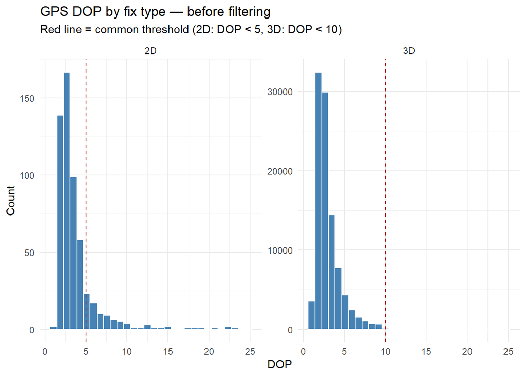

```r
# Plot
plot.raw <- ggplot(WB.mv2, aes(x = gps_dop)) +
  geom_histogram(bins = 30, fill = "steelblue", color = "white") +
  geom_vline(data = tibble(gps_fix_type_raw = c("2D", "3D"), thresh = c(5, 10)),
             aes(xintercept = thresh), color = "firebrick", linetype = "dashed") +
  facet_wrap(~ gps_fix_type_raw, scales = "free_y") +
  labs(title = "GPS DOP by fix type — before filtering",
       subtitle = "Red line = common threshold (2D: DOP < 5, 3D: DOP < 10)",
       x = "DOP", y = "Count") +
  theme_minimal()

# Print to view the plot
plot.raw
```

### 4.2 DOP Filter

Filter out data points that meet our criteria, removed 3D fixes with a DOP > 10 and 2D fies with a DOP > 5. This allows us to be more restrictive with the poorer quality data.

```r
# Note: fixes with a missing DOP value, or a fix type other than "2D"/"3D",
# evaluate to NA here and are dropped by filter() along with the low-precision fixes.
WB.mv2 <- WB.mv2 %>%
  filter(
    (gps_fix_type_raw == "3D" & gps_dop < 10) |
    (gps_fix_type_raw == "2D" & gps_dop < 5)
  )

cat("After DOP/fix-type filter:", n_distinct(mt_track_id(WB.mv2)), "animals,", nrow(WB.mv2), "fixes\n")
```

```
## After DOP/fix-type filter: 12 animals, 99377 fixes
```

Create a histogram of the data points after filtering has been completed.

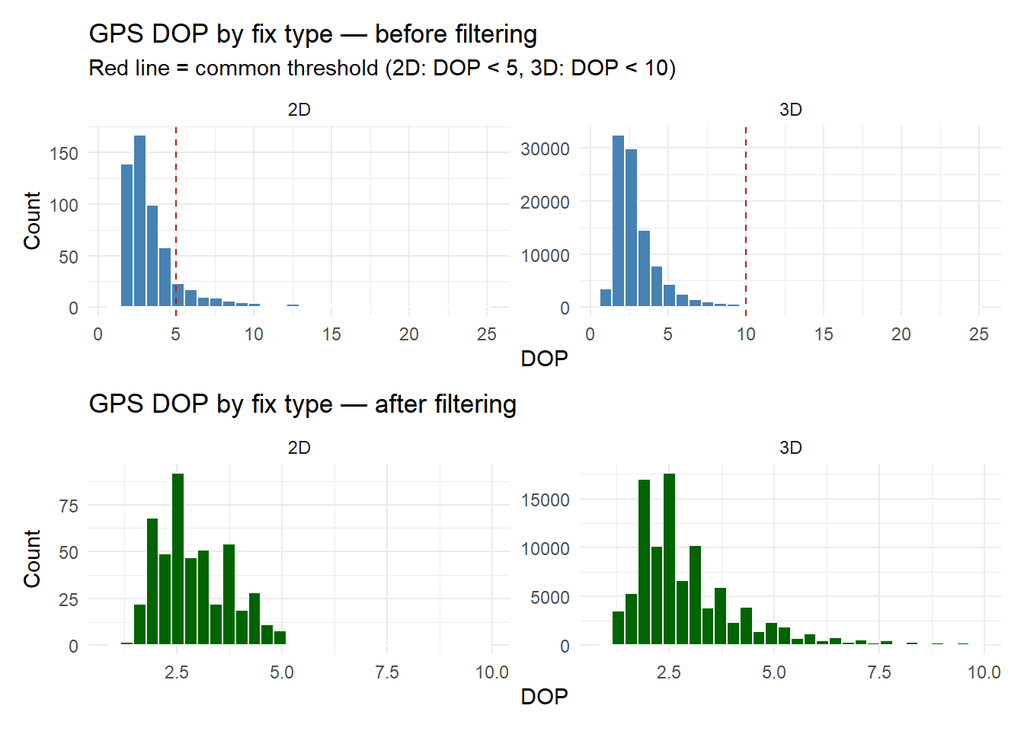

```r
# First recorder so that graph plots in same was as plot.raw
WB.mv2$gps_fix_type_raw <- reorder(WB.mv2$gps_fix_type_raw, WB.mv2$gps_dop)

# Now plot the filtered subset
plot.filt <- WB.mv2 %>%
  as_tibble() %>%
  ggplot(aes(x = gps_dop)) +
  geom_histogram(bins = 30, fill = "darkgreen", color = "white") +
  facet_wrap(~ gps_fix_type_raw, scales = "free_y") +
  labs(title = "GPS DOP by fix type — after filtering",
       x = "DOP", y = "Count") +
  theme_minimal()

# Plot results with plot.raw to see results together
# Use the patchwork package (| for side by side, / for stacked)
plot.raw / plot.filt
```

Update the QC log:

```r
qc_log <- qc_log %>%
  add_row(step      = "2. GPS precision filter (DOP × fix type)",
           n_fixes   = nrow(WB.mv2),
           n_animals = n_distinct(mt_track_id(WB.mv2)))
```

> **Heads up for your own data:** Not every tag manufacturer reports DOP and fix type the same way (or at all). E-obs and some solar tags report a different precision metric or none. Some vendors give HDOP/VDOP separately rather than a single DOP. Check your tag manufacturer’s documentation for what quality fields are available, and adapt the filter accordingly.

## 5. Remove duplicates and invalid fixes

Removal of points from a dataset should be done with extreme caution. Here, we demonstrate how potential erroneous data points could be removed before conducting more formal analyses.

```r
# How many rows exist in the datast?
n_before_dedup <- nrow(WB.mv2)

WB.mv2 <- WB.mv2 %>%
  # Drop exact duplicate animal-timestamp combinations
  distinct(individual_local_identifier, timestamp, .keep_all = TRUE) %>%
  # Drop missing or (0,0) coordinates
  mutate(.lon = st_coordinates(.)[, 1],
         .lat = st_coordinates(.)[, 2]) %>%
  filter(!is.na(.lon), !is.na(.lat), !(.lon == 0 & .lat == 0)) %>%
  select(-.lon, -.lat) %>%
  # Re-establish track + time order (required by many move2/amt functions downstream)
  arrange(individual_local_identifier, timestamp)

cat("Removed", n_before_dedup - nrow(WB.mv2), "duplicate/invalid fixes\n")
```

```
## Removed 0 duplicate/invalid fixes
```

Update the QC log:

```r
qc_log <- qc_log %>%
  add_row(step      = "3. Remove duplicates + invalid coordinates",
           n_fixes   = nrow(WB.mv2),
           n_animals = n_distinct(mt_track_id(WB.mv2)))
```

## 6. Quantify the cumulative effect of QC

Now let’s view our QC log to evaluate where large changes in the size of the dataset occurred.

```r
qc_log <- qc_log %>%
  mutate(pct_of_raw = round(100 * n_fixes / first(n_fixes), 1))

qc_log
```

```
## # A tibble: 4 × 4
##   step                                        n_fixes n_animals pct_of_raw
##   <chr>                                         <int>     <int>      <dbl>
## 1 0. Raw data (Module 1 output)                276706        36      100
## 2 1. Subset to study site + deployment window   99710        12       36
## 3 2. GPS precision filter (DOP × fix type)      99377        12       35.9
## 4 3. Remove duplicates + invalid coordinates    99377        12       35.9
```

```r
qc_log %>%
  gt() %>%
  opt_row_striping() %>%
  tab_header(title = "QC pipeline: effect on dataset size",
             subtitle = "White-bearded wildebeest, Athi-Kaputiei Plains") %>%
  cols_label(step       = "Step",
             n_fixes    = "Fixes remaining",
             n_animals  = "Animals remaining",
             pct_of_raw = "% of raw fixes") %>%
  cols_align(align = "center", columns = c(n_fixes, n_animals, pct_of_raw))
```

QC pipeline: effect on dataset size

White-bearded wildebeest, Athi-Kaputiei Plains

| Step | Fixes remaining | Animals remaining | % of raw fixes |
| --- | --- | --- | --- |
| 0. Raw data (Module 1 output) | 276706 | 36 | 100.0 |
| 1. Subset to study site + deployment window | 99710 | 12 | 36.0 |
| 2. GPS precision filter (DOP × fix type) | 99377 | 12 | 35.9 |
| 3. Remove duplicates + invalid coordinates | 99377 | 12 | 35.9 |

> **Discussion:** Which step removed the most data — the site/deployment subset, or the DOP filter? Is that what you expected? In your own dataset, which QC step do you think will matter most and why?

## 7. Confirm the cleaned dataset

Now let’s look at our final dataset, using a simple color ramp to view each animal. We can do this very quickly with `mapview`.

```r
WB.sf_clean <- st_as_sf(as.data.frame(WB.mv2))

WB.sf_clean %>%
  slice_sample(n = 2000) %>%
  mapview(zcol = "individual_local_identifier", layer.name = "Individual", cex = 2, alpha = 0.7)
```

[interactive chart not shown]

All points now fall within the Athi-Kaputiei Plains, with no obvious outliers. If you see anything unexpected, go back and re-examine the QC steps above before moving on.

## 8. Save output for Module 3

Save your output for further analyses.

```r
save(WB.mv2, file = "Data/WB_clean.rdata")
cat("Saved cleaned WB.mv2 —", n_distinct(mt_track_id(WB.mv2)), "animals,", nrow(WB.mv2), "fixes\n")
```

```
## Saved cleaned WB.mv2 — 12 animals, 99377 fixes
```

# Exercise: Apply to your own data

Now run the same QC workflow on your own dataset. Please do the following:

1. **Inspect your track metadata** with `mt_track_data()`. Does it include the fields you need to subset (study site, deployment dates, sex)? If a field is missing, where else might that information be located (a separate reference sheet, metadata you recorded yourself)?
2. **Check what precision metric your tags report.** Look for DOP, HDOP, fix type, or a manufacturer-specific quality field. If your tags don’t report precision at all, what other QC steps (speed filters, spatial outlier checks) might substitute?
3. **Run the duplicate/invalid-coordinate check.** This step is universal, regardless of tag type.
4. **Build your own QC accounting table.** How much data survives each step? Is that consistent with what you’d expect given your species and study design?

# Key functions reference

| Function | Package | Purpose |
| --- | --- | --- |
| `mt_track_data()` | `move2` | Return track-level attributes |
| `st_as_sf()` | `sf` | Convert a data frame to a spatial object |
| `st_coordinates()` | `sf` | Extract coordinate matrix from an sf object |
| `mapview()` | `mapview` | Interactive mapping of spatial objects |
| `geom_histogram()` | `ggplot` | Plot histograms |
| `geom_vline()` | `ggplot` | Add vertical reference lines |
| `facet_wrap()` | `ggplot` | Create faceted plots |
| `reorder()` | `ggplot` | Reorder factor levels based on another variable |
| `gt()` | `gt` | Create a formatted table |

*Next:* **Module 3 — Trajectory Creation & Visualization.** We will convert the cleaned data into an `amt` track, check sampling regularity, and visualize trajectories.